# MCEM part2

From this report we know that in the case of monte-carlo with 10 trees, $\lambda=0.8$, $\beta=0.0175$ and $\mu=0.1$ simulated trees, the estimations of MCEM are really good for $\lambda$ and $\beta$, but slyghtly biased for $\mu$

```r
0.1-0.08918
```

```
## [1] 0.01082
```

we complain that if $\mu$ would not be biased, then we would have perfect MCEM performance. Our trys on finding the right re-weithing method to make $\mu$ unbiased have not been succeful yet. However, we can probe if our complains make senses or not.

To do that, we just add the correct number to make it unbiased…

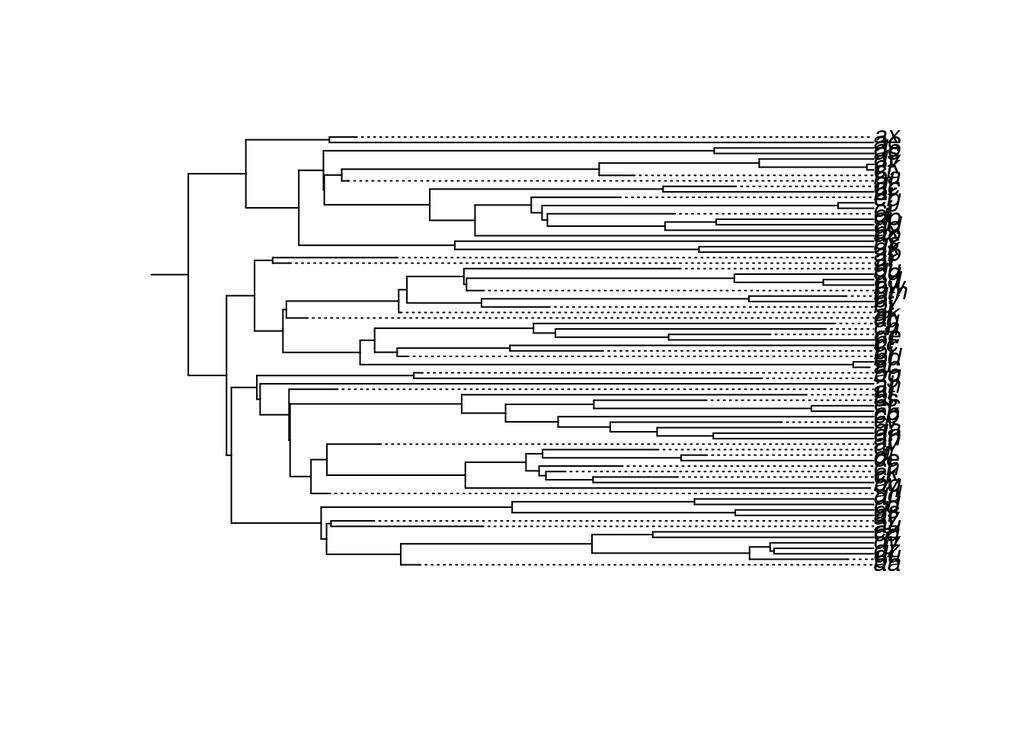

```r
st <- sim_phyl()
plot(st$newick,align.tip.label=T,root.edge=T)
```

```r
st2 <- phylo2p(drop.fossil(st$newick))
em <- EM_phylo(wt=st2$t,init_par=c(8,0.175,0.9),n_trees=10,dummy=0.1-0.08918,n_it = 500,printpar = F)
```

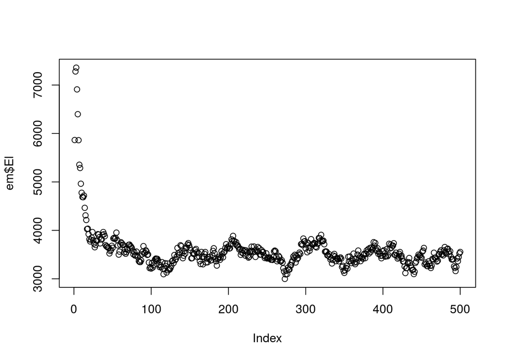

```r
plot(em$El)
```

the parameters

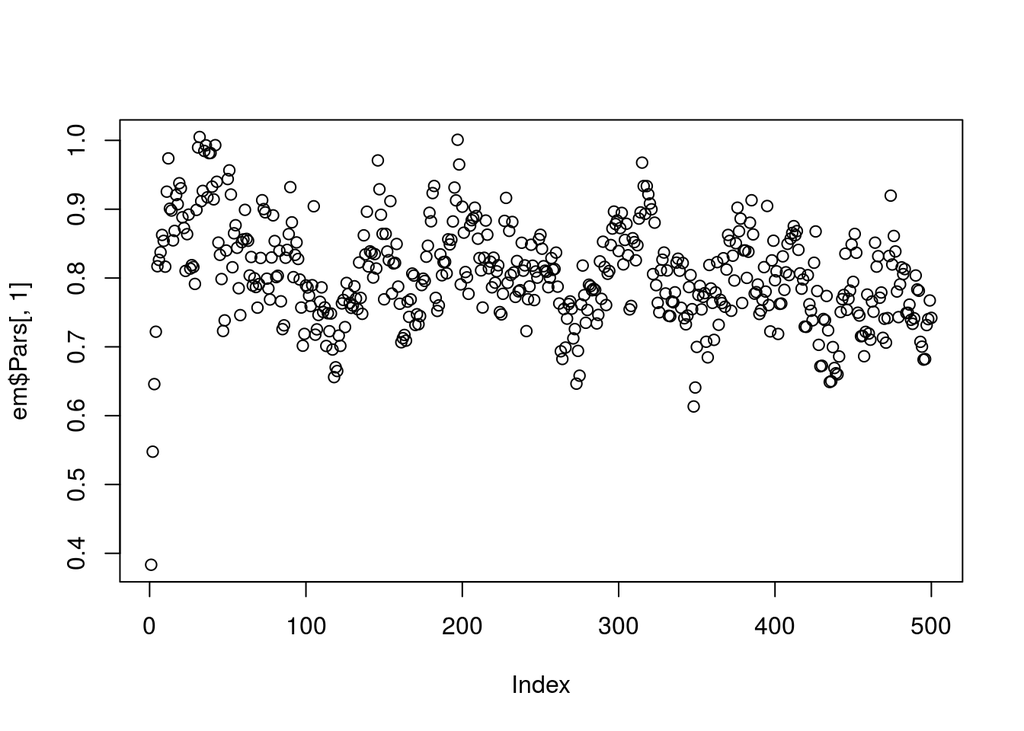

```r
plot(em$Pars[,1])
```

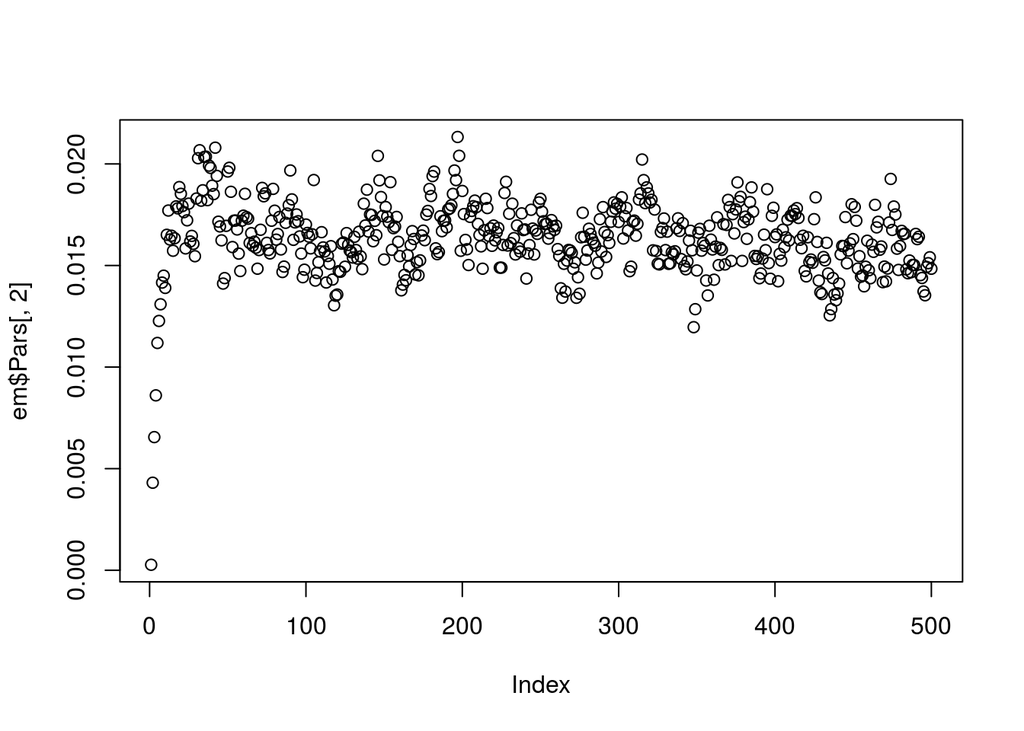

```r
plot(em$Pars[,2])
```

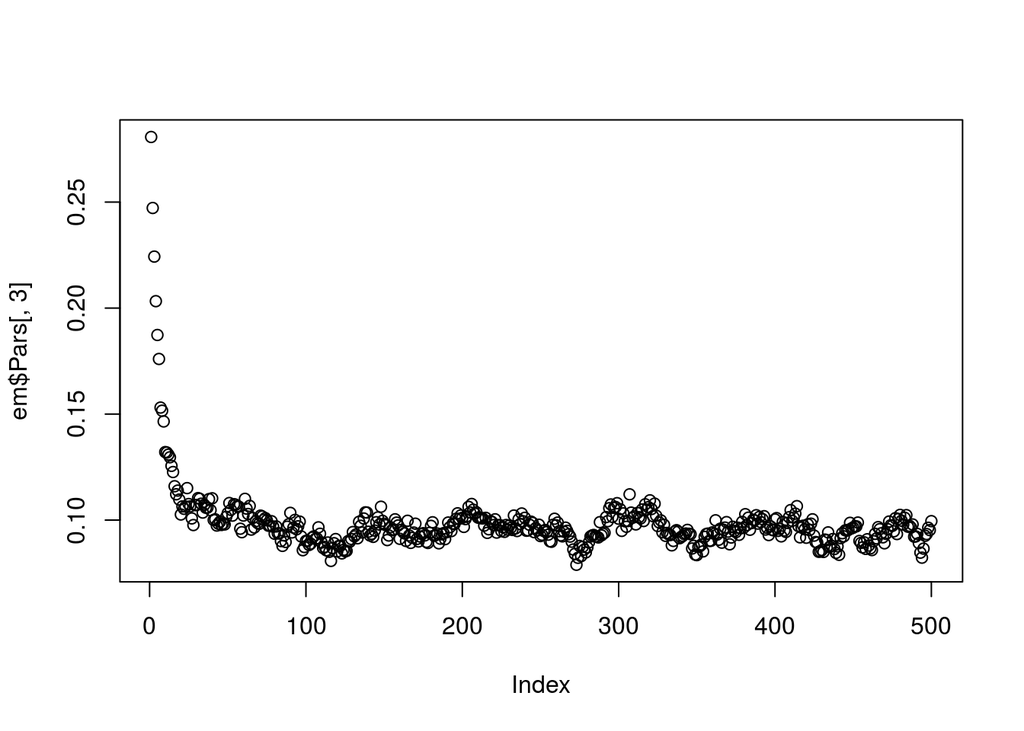

```r
plot(em$Pars[,3])
```

if we do it normally?

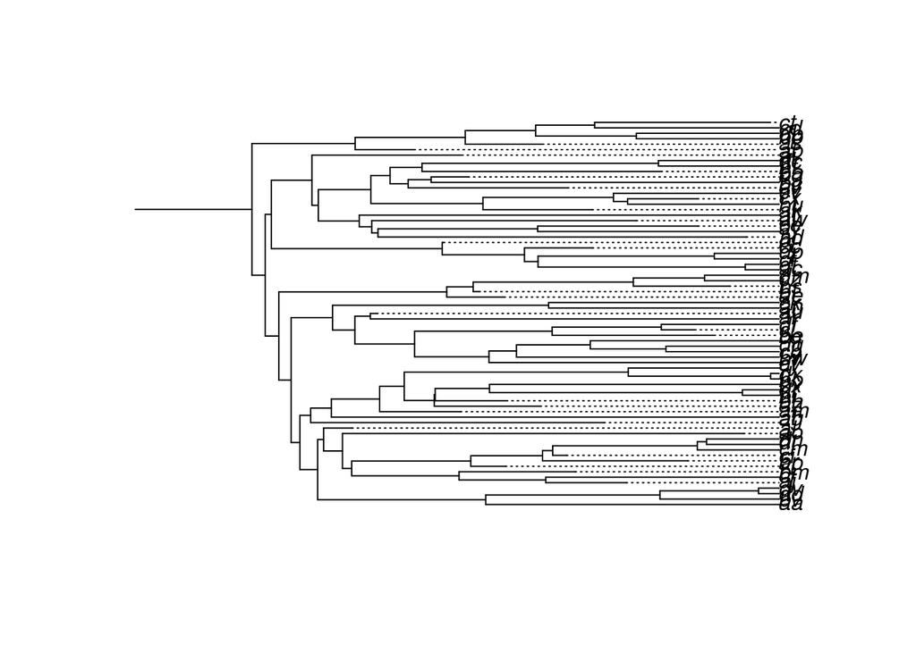

```r
st <- sim_phyl()
plot(st$newick,align.tip.label=T,root.edge=T)
```

```r
st2 <- phylo2p(drop.fossil(st$newick))
em <- EM_phylo(wt=st2$t,init_par=c(8,0.175,0.9),n_trees=10,dummy=0,n_it = 500,printpar = F)
```

the $E[l]$ value

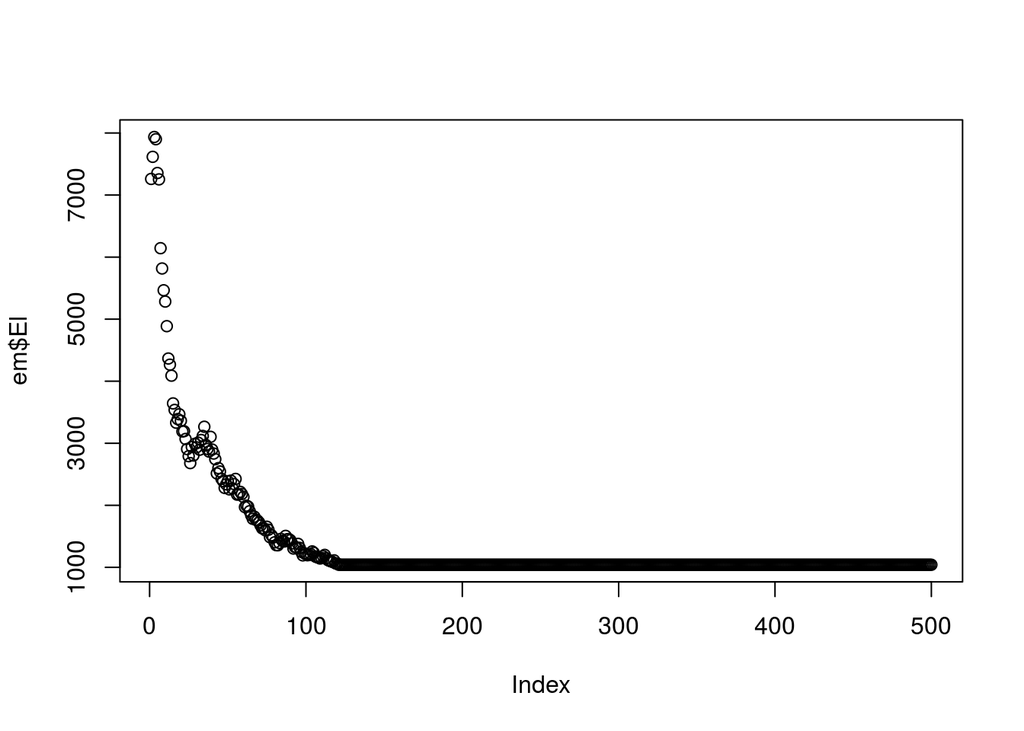

```r
plot(em$El)
```

tha parameters

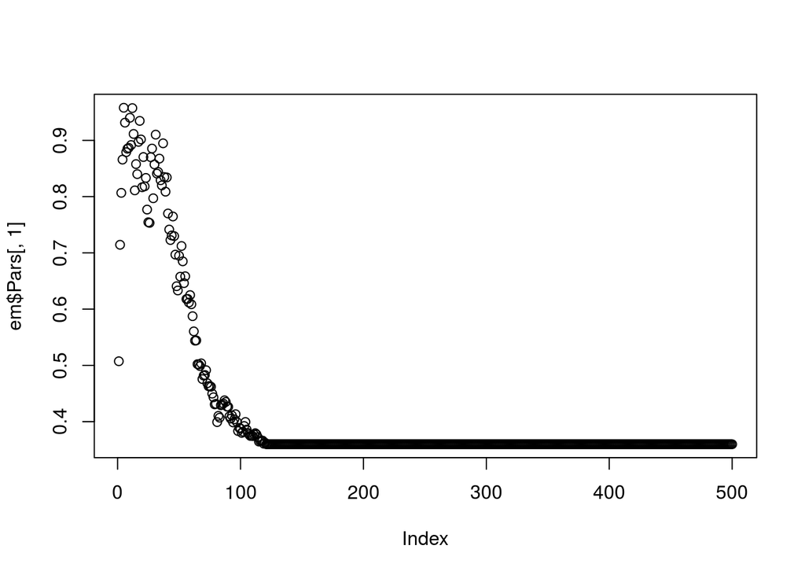

```r
plot(em$Pars[,1])
```

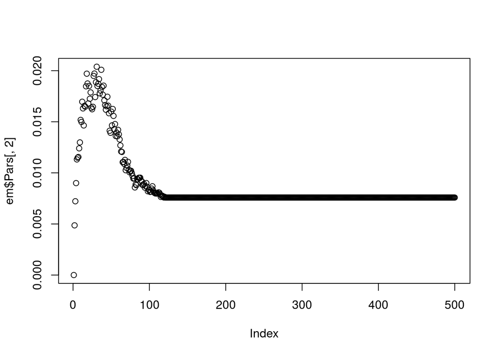

```r
plot(em$Pars[,2])
```

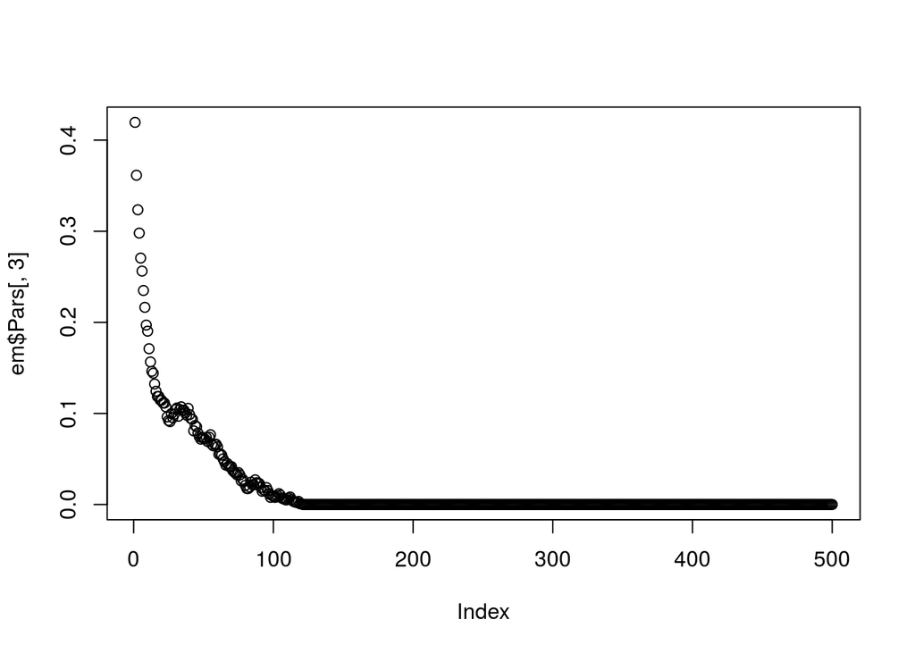

```r
plot(em$Pars[,3])
```

what if we try the adjusted one with other initial values?

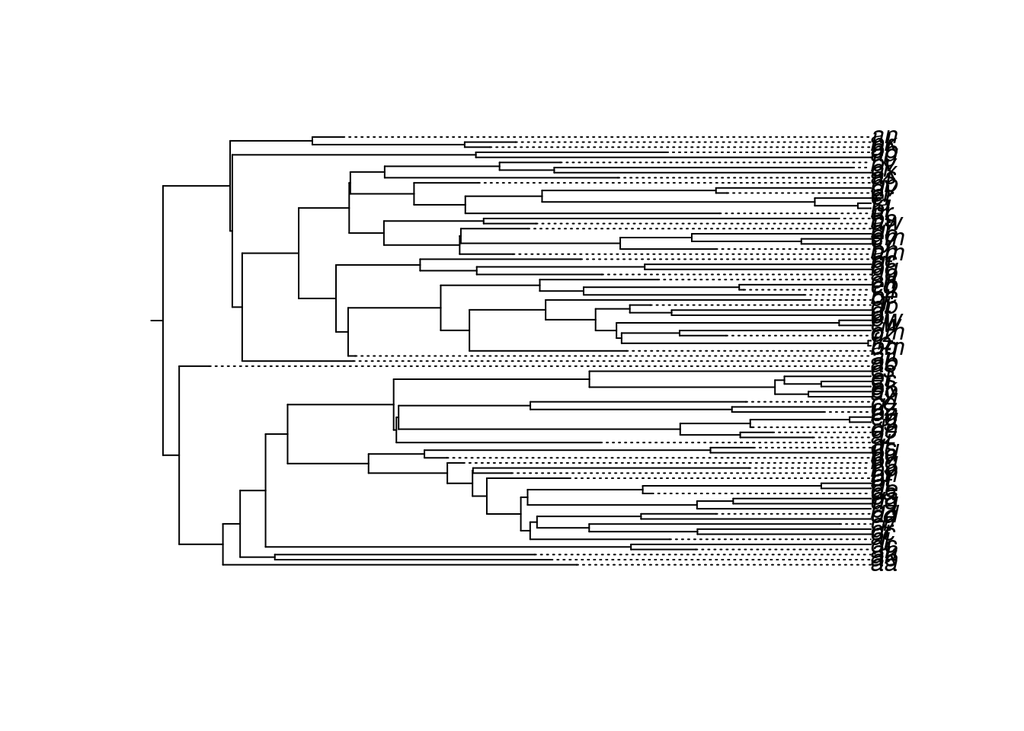

```r
st <- sim_phyl()
plot(st$newick,align.tip.label=T,root.edge=T)
```

```r
st2 <- phylo2p(drop.fossil(st$newick))
em <- EM_phylo(wt=st2$t,init_par=c(0.5,0.02,0.2),n_trees=10,dummy=0.1-0.08918,n_it = 500,printpar = F)
```

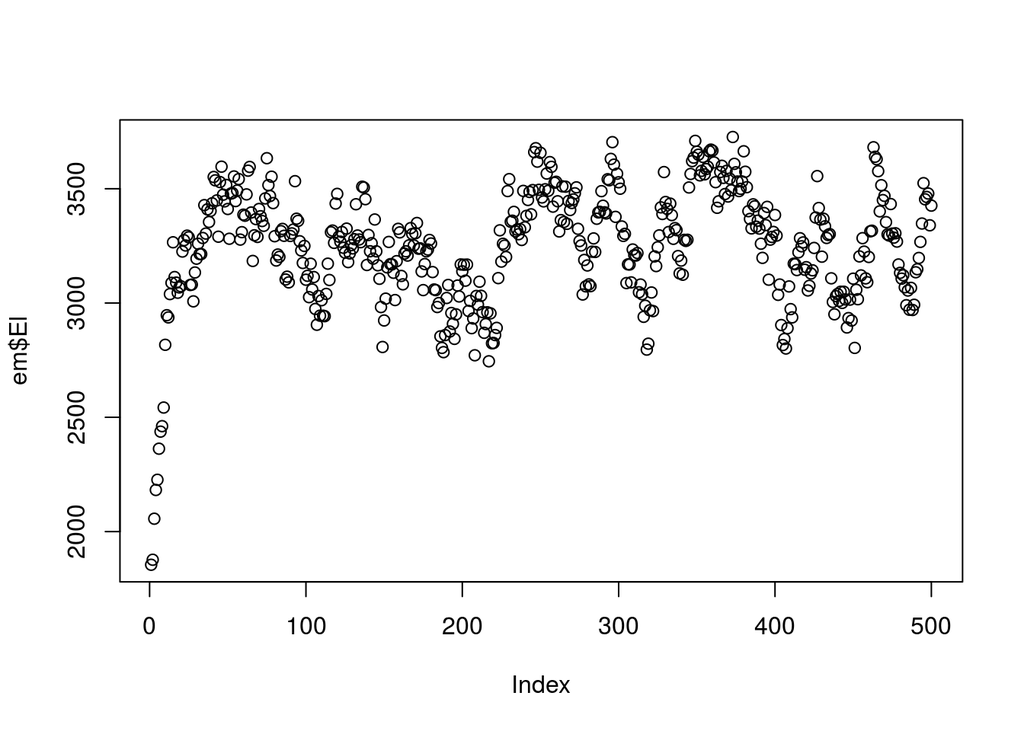

```r
plot(em$El)
```

the parameters

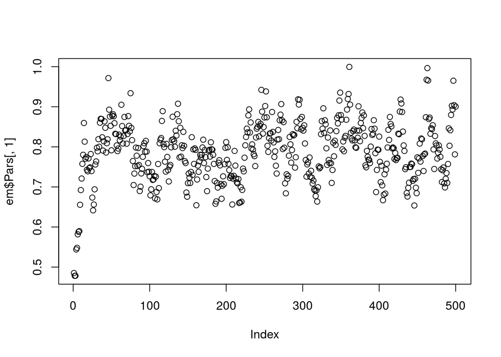

```r
plot(em$Pars[,1])
```

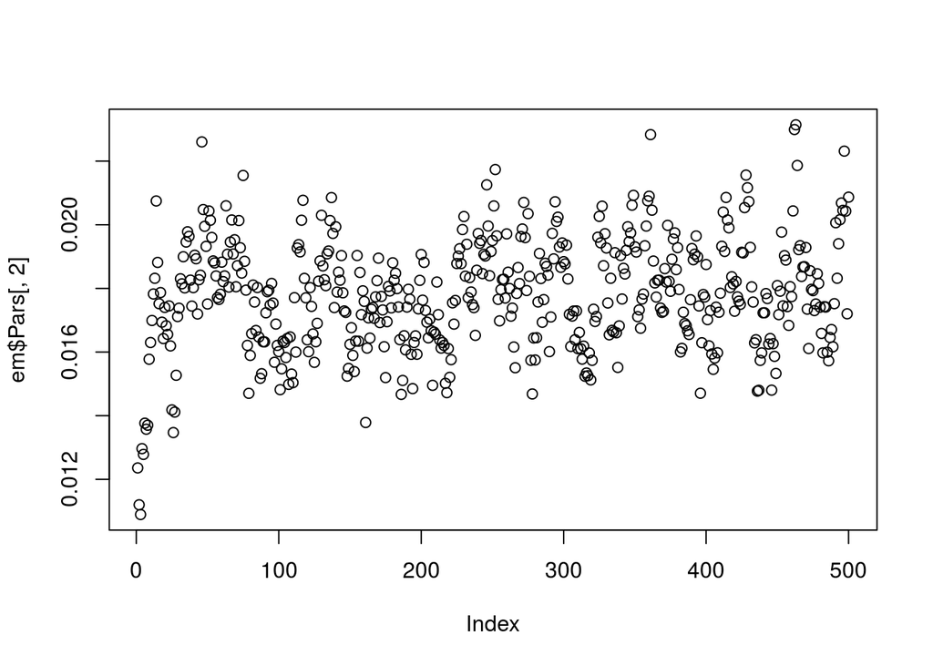

```r
plot(em$Pars[,2])
```

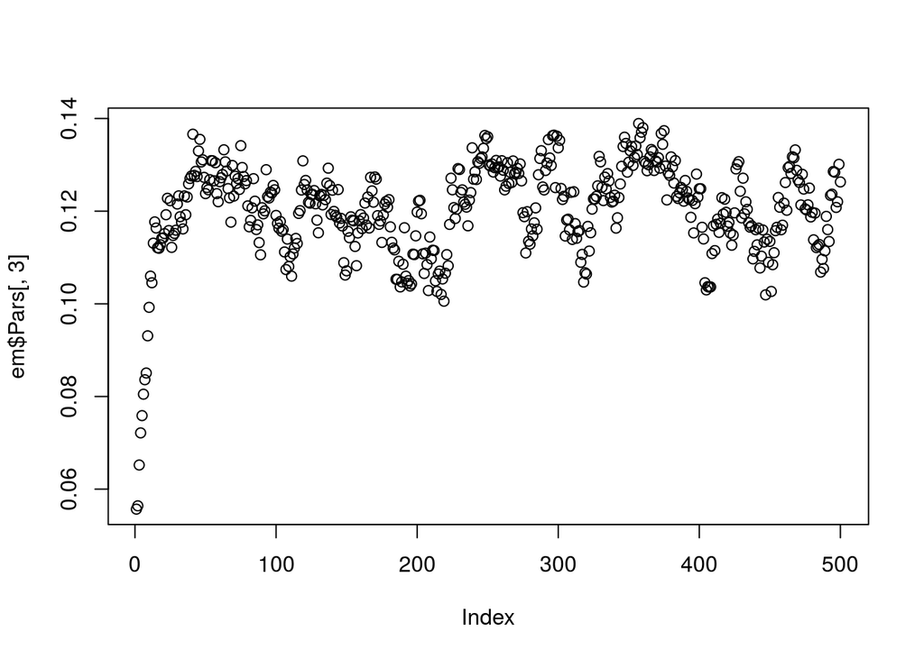

```r
plot(em$Pars[,3])
```

normally, but with thoso others parameters?

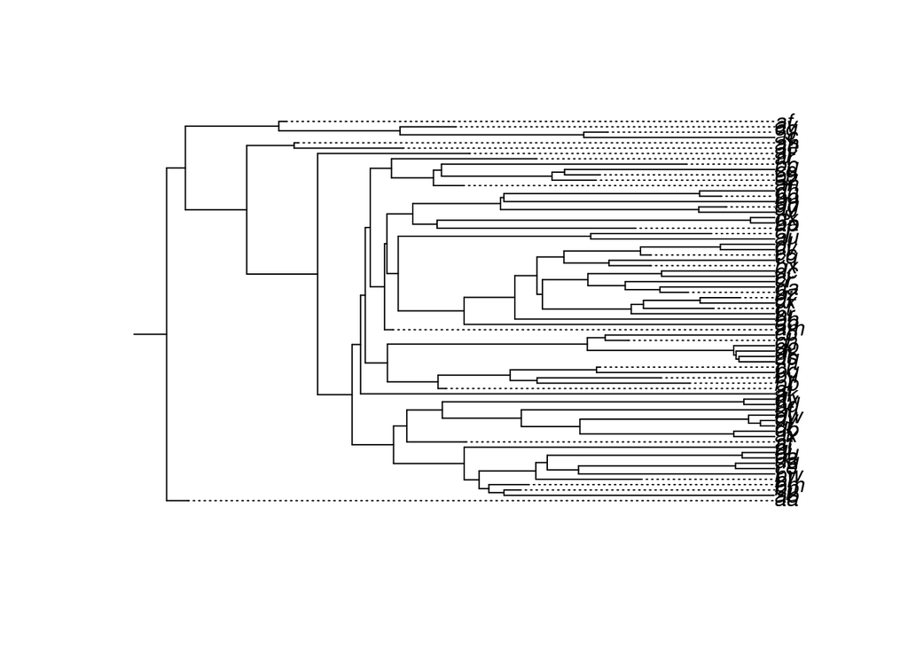

```r
st <- sim_phyl()
plot(st$newick,align.tip.label=T,root.edge=T)
```

```r
st2 <- phylo2p(drop.fossil(st$newick))
em <- EM_phylo(wt=st2$t,init_par=c(0.5,0.02,0.2),n_trees=10,dummy=0,n_it = 500,printpar = F)
```

the $E[l]$ value

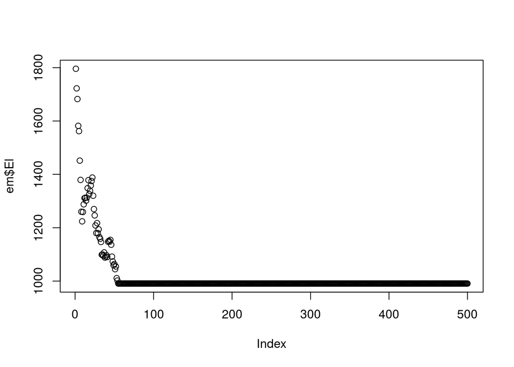

```r
plot(em$El)
```

tha parameters

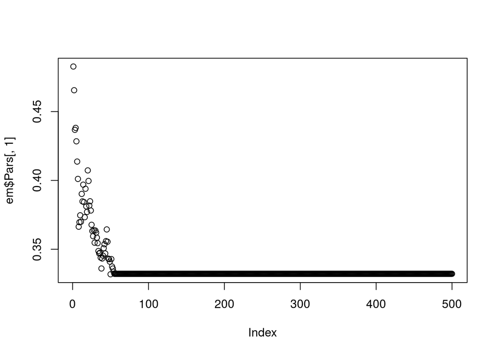

```r
plot(em$Pars[,1])
```

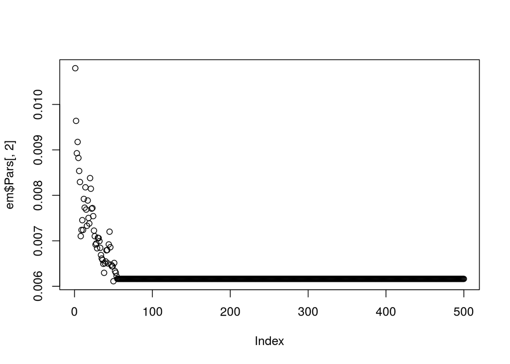

```r
plot(em$Pars[,2])
```

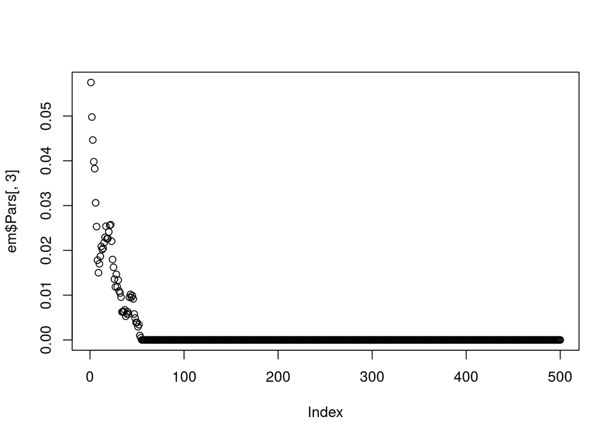

```r
plot(em$Pars[,3])
```

nothing…

if we start with rates greater than 1?

what if we try the adjusted one with other initial values?

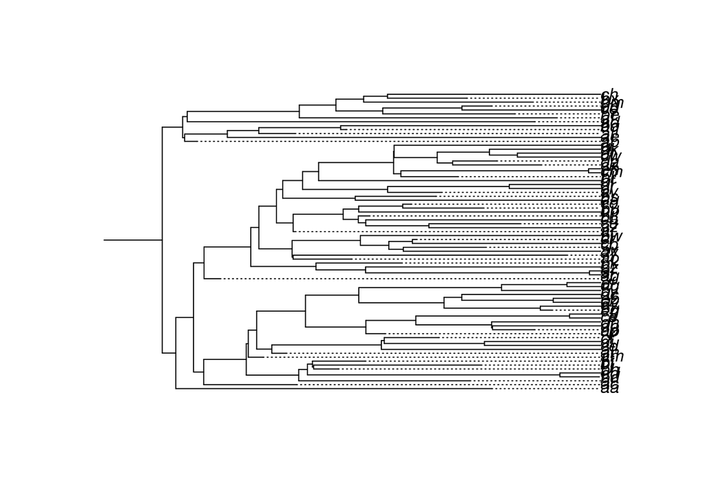

```r
st <- sim_phyl()
plot(st$newick,align.tip.label=T,root.edge=T)
```

```r
st2 <- phylo2p(drop.fossil(st$newick))
em <- EM_phylo(wt=st2$t,init_par=c(1.1,0.02,1),n_trees=10,dummy=0.1-0.08918,n_it = 500,printpar = F)
```

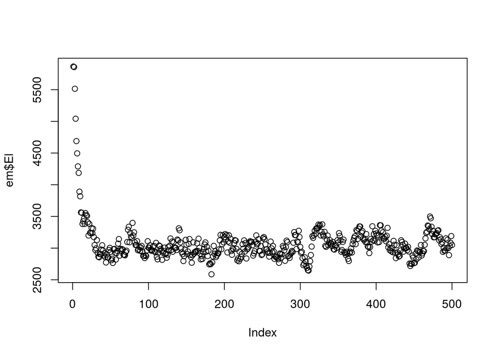

```r
plot(em$El)
```

the parameters

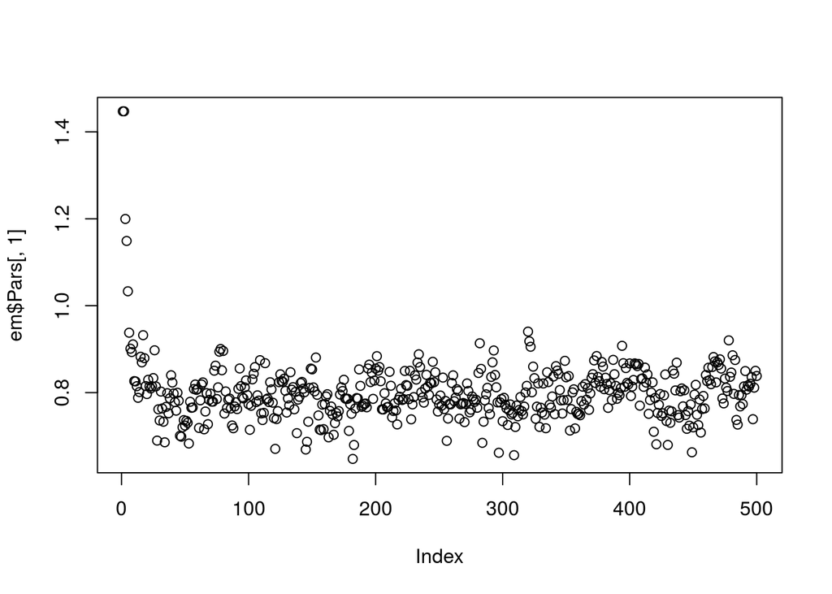

```r
plot(em$Pars[,1])
```

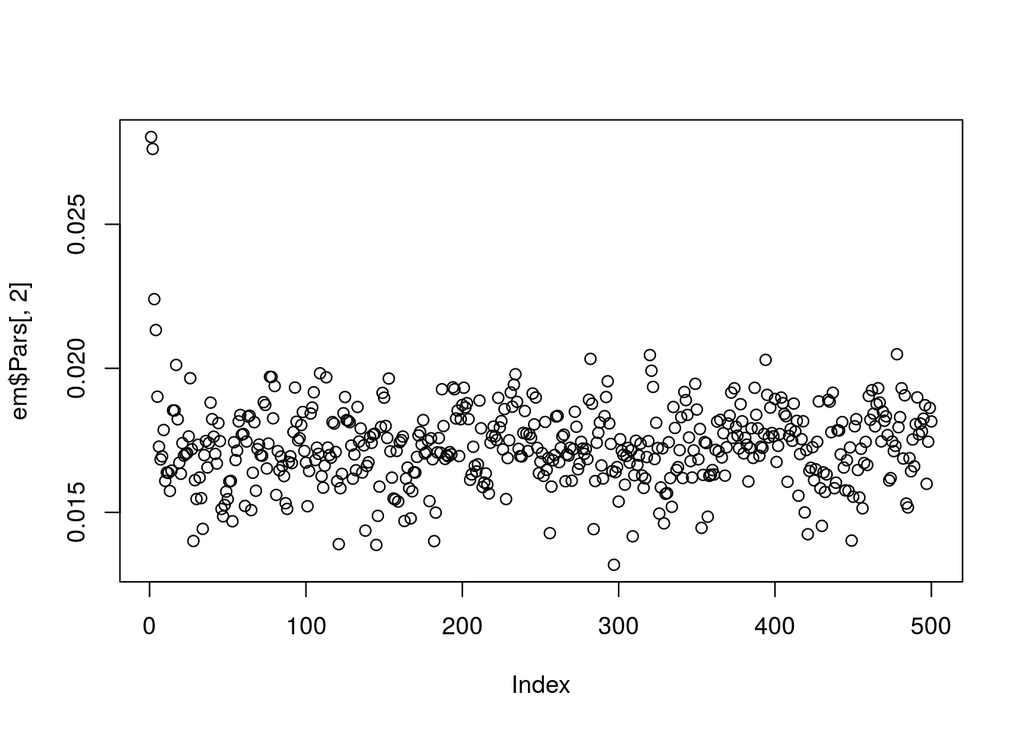

```r
plot(em$Pars[,2])
```

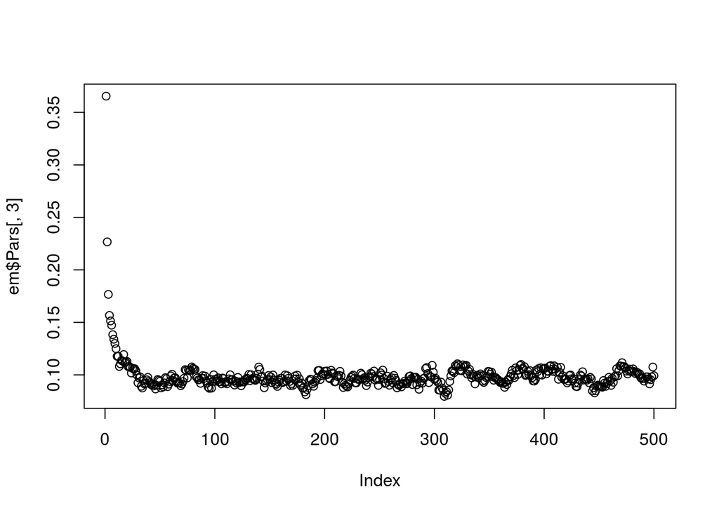

```r
plot(em$Pars[,3])
```

or

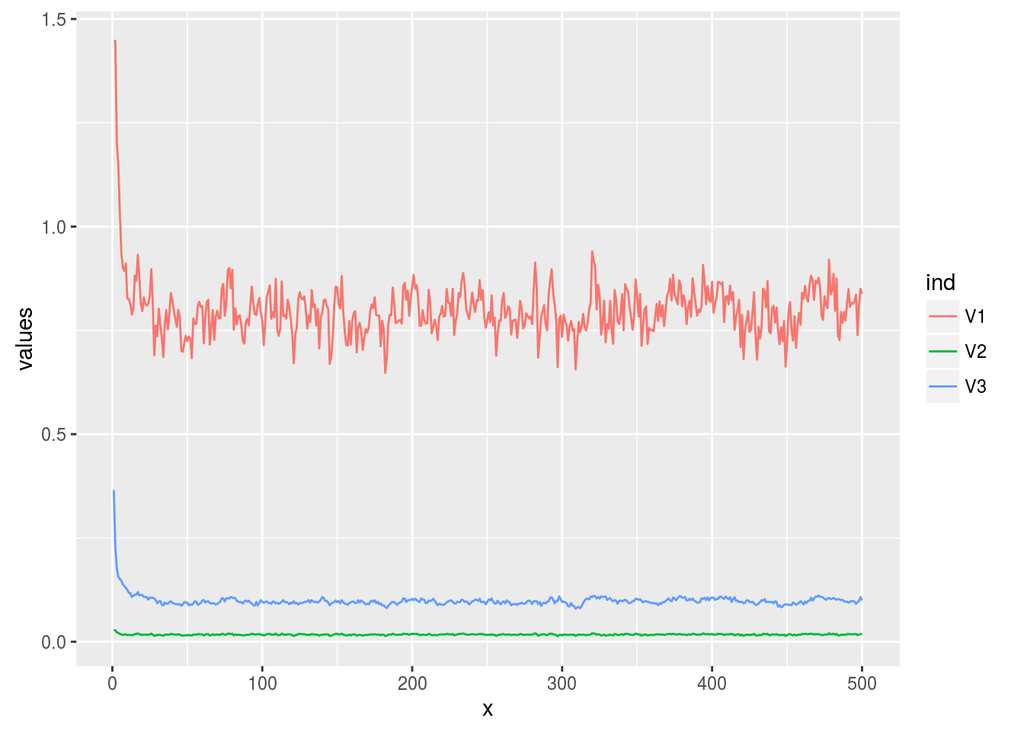

```r
sa <- stack(as.data.frame(em$Pars))
sa$x <- rep(seq_len(nrow(em$Pars)), ncol(em$Pars))
qplot(x, values, data = sa, group = ind, colour = ind, geom = "line")
```

***

(I will start doing less number of iterations)

now even greater rates

what if we try the adjusted one with other initial values?

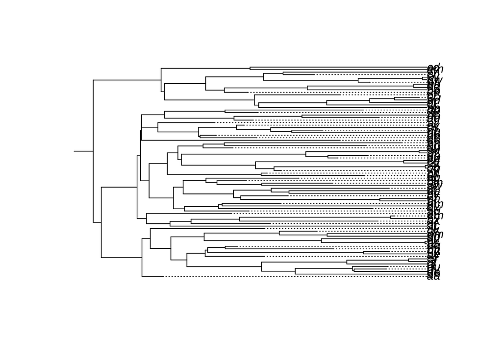

```r
st <- sim_phyl()
plot(st$newick,align.tip.label=T,root.edge=T)
```

```r
st2 <- phylo2p(drop.fossil(st$newick))
em <- EM_phylo(wt=st2$t,init_par=c(1.6,0.02,1.2),n_trees=10,dummy=0.1-0.08918,n_it = 200,printpar = F)
```

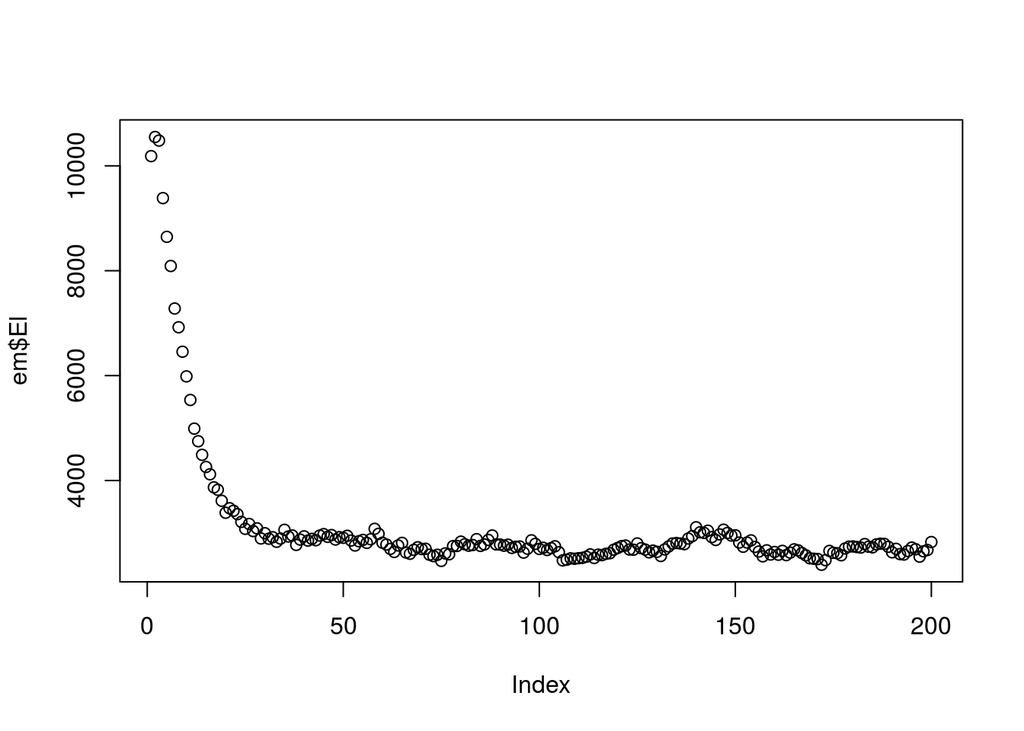

```r
plot(em$El)
```

the parameters

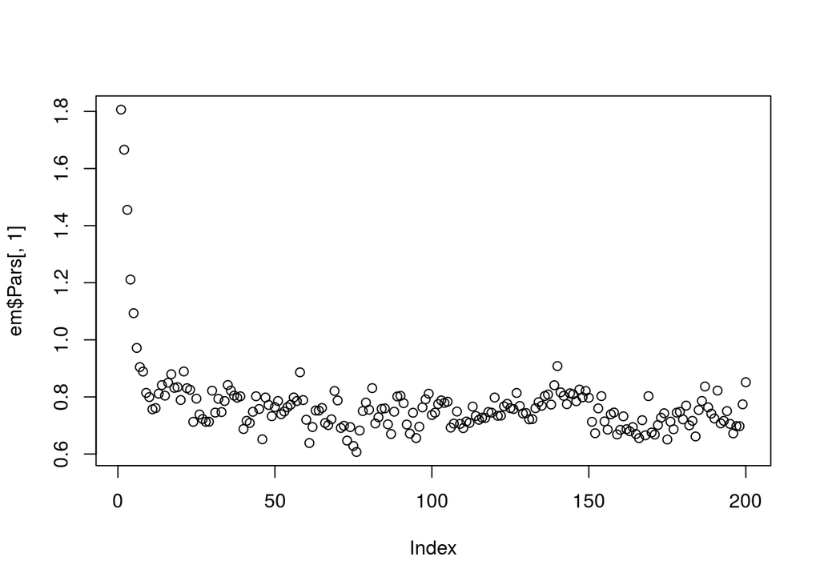

```r
plot(em$Pars[,1])
```

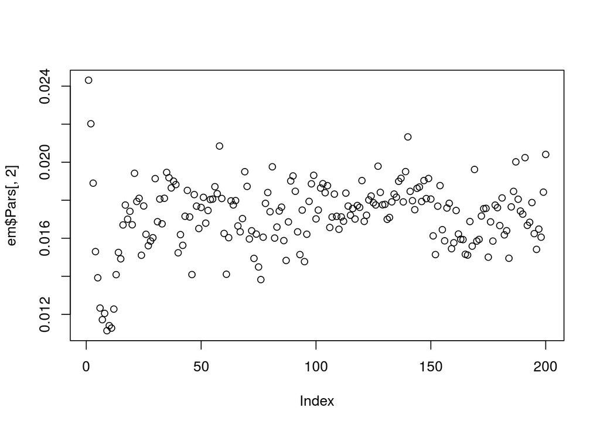

```r
plot(em$Pars[,2])
```